# Associations of variates with mutual information

## Brief overview of the theory behind Mutual Information

### Association and traditional measures for it

A probability quantifies our degree of belief in the *values* of some variates, given that we know the *values* of some other variates. This belief also reflect our uncertainty: maximal for a belief of 50%, minimal for a belief of 0% or 100%.

In some cases we wish to quantify our uncertainty *in an average sense*, rather than about specific values, or given knowledge of specific values. In other words, we ask: on average, how uncertain are we about a set of variates, given that we have knowledge of another set? If this average uncertainty is low, then we say that the two sets of variates are highly *correlated* or *associated*; otherwise, that the are *uncorrelated*. Here we are using the word ‘correlation’ in its general sense, not in the specific sense of “linear correlation” or similar.

Traditionally the [Pearson correlation coefficient “$r$”](https://mathworld.wolfram.com/CorrelationCoefficient.html) is used to quantify association. It is extremely limited, however. It is essentially [based on the assumption that all variates involved have a joint Gaussian distribution](https://doi.org/10.1080/01621459.1954.10501231). As a consequence, it is a measure of *linear* association, rather than general association. For instance, if the graph of two continuous variates $X$ and $Y$ is a semicircle, then it means that $Y$ is a function of $X$, and is therefore perfectly associated with $X$: if we know $X$, then we can perfectly predict the value of $Y$. Yet the Pearson correlation coefficient between the two variates is $0$ in this case, simply because the functional dependence of $Y$ on $X$ is not linear:

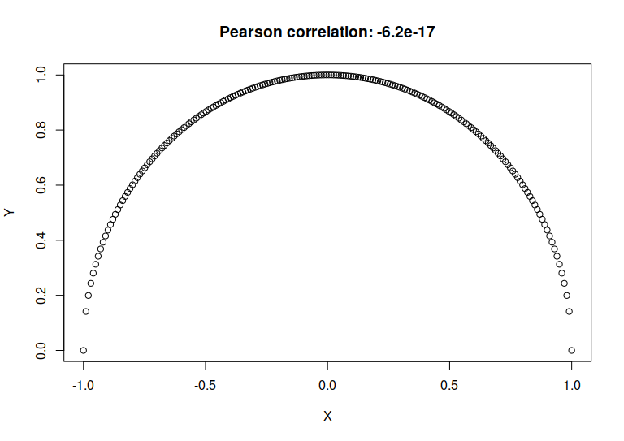

```r
X <- seq(-1, 1, length.out = 200)
Y <- sqrt(1 - X^2)
r <- cor(X, Y, method = 'pearson')
plot(x = X, y = Y, type = 'p', main = paste0('Pearson correlation: ', signif(r, 2)))
```

Similar limitations of the Pearson correlation coefficient are demonstrated by the [“Anscombe quartet”](https://doi.org/10.2307/2682899) of datasets.

In the case of two variates, the limitations and possibly misleading value of the Pearson correlation coefficient may not be a serious problem, because we can visually inspect the relation and association between the variates. But in dealing with multi-dimensional variates, visualization is not possible and we must rely on the numerical values of the measure we use to quantify “association”. In such cases the Pearson correlation coefficient can be highly misleading, and let us conclude that there’s no association when actually there’s a very strong one. Considering that our world is highly non-linear, this possibility is far from remote.

### Mutual Information

But there is a measure of association that does not suffer from the limitations discussed above: the **mutual information** between $X$ and $Y$. It has in fact the following important properties:

- If there is no association whatever between $X$ and $Y$, in the sense that knowledge of one never changes our probabilities about the other, then the mutual information between them is zero. Vice versa, if the mutual information is zero, then there is no association whatever between $X$ and $Y$.
- If $X$ and $Y$ have a perfect association, that is, if knowing $X$ gives us perfect knowledge about $Y$ or vice versa, or in yet other words if $Y$ is a function of $X$ or vice versa, then the mutual information between them takes on its maximal possible value. Vice versa, if the mutual information takes on its maximal value, then one variate is a function of the other.

Regarding the last feature, note that the functional dependence between $X$ and $Y$ can be *of any kind*, not just linear. This means that in the case of the semicircle plot above, the mutual information between $X$ and $Y$ has its maximal value.

There’s also a special case in which the *maximal* value of the mutual information is zero, which indicates that $Y$ is, technically speaking, a function of $X$, yet knowledge of $X$ doesn’t give us any knowledge about $Y$. It’s the case where $Y$ has just one value, independently of $X$:

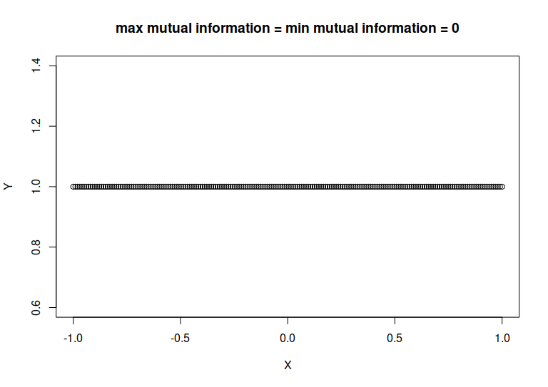

### Interpretation of the values of mutual information

The value of the mutual information between two variates has an operational meaning and interpretation. To understand it we must first summarize the meaning of the *Shannon information* as a measure of uncertainty or of acquired information.

A value of $s$ shannons represents the uncertainty *equivalent* to not knowing which among $2^s$ possible alternatives is the true one. So $1\,\mathrm{Sh}$ represents the uncertainty between two equally possible cases, like the outcome of a coin toss. Other examples: $3\,\mathrm{Sh}$ represent being uncertain among 8 equally possible alternatives; $1.58\,\mathrm{Sh}$ represent being uncertain among 3 equally possible alternatives. If a clinician is uncertain about which disease, among four equally possible ones, affects a patient, then the clinician’s uncertainty is $2\,\mathrm{Sh}$.

The “equivalence” in the definition above reflects the fact that some possibilities may have higher probabilities than others. For instance, if there are three alternatives but one of them has 0% probability, then our uncertainty is $1\,\mathrm{Sh}$, the same as for *two* equally possible alternatives. If there are three possibilities with probabilities 11.4%, 11.4%, and 77.2%, then the uncertainty is approximately $1\,\mathrm{Sh}$: as if there were only two alternatives; this is because one alternative has much higher probability than the other two.

Back to mutual information: If the mutual information between $X$ and $Y$ amounts to $h\,\mathrm{Sh}$, then knowledge of $X$ reduces, on average, $2^h$ times the number of uncertain possibilities of $Y$. For example, suppose that a clinician is uncertain about four possible diseases in a diagnosis (uncertainty of $2\,\mathrm{Sh}$), but there is a particular clinical indicator that associated with the disease. If the mutual information between the indicator and the disease is $1\,\mathrm{Sh}$, then the clinician will be roughly uncertain about two possible diseases, rather than four, upon testing the clinical indicator. If the mutual information were $2\,\mathrm{Sh}$ instead, then the indicator would tell the disease with certainty.

You might think: “the value of mutual information is difficult to interpret”. But this is only a matter of getting familiar with it, by using it. Remember how difficult it was to get a feeling of what a particular value of the Pearson correlation $r$ really meant, when you first learned it. You developed an intuitive understanding of its range of values simply by using it. The same holds for mutual information.

For further discussion about mutual information and entropic measures of association, take a look at [*Information, relevance, independence, association*](https://pglpm.github.io/ADA511/information.html) and the references given there.

## Function for the calculation of mutual information between variates

The software offers the function `mutualinfo()` to calculate the mutual information between a set of joint variates $Y_1$ and another set $Y_2$. It requires at least three arguments:

- `Y1names`: a vector the names (strings) of the variates in the first set;
- `Y2names`: a vector the names of the variates in the second set;
- `learnt`: the knowledge acquired from the dataset, calculated with the `learn()` function.

It may be useful to specify two more arguments:

- `parallel`: the number of CPUs to use for the computation;
- `nsamples`: the number of samples to use for the computation of the mutual information (default 3600).

The output of this function is a list of several entropic measures and other information. For this example we can focus on two outputs:

- `$MI`: a vector of two numbers: `value` is the value of the mutual information in shannons; `error` is its numerical error (coming from the Monte Carlo calculation);
- `$MImax`: a vector of two numbers: `value` is the value of the maximal possible value of the mutual information, in shannons; `error` is its numerical error.

### Example

As an example, let’s take the dataset and inference problem discussed in the vignette *Example of use: inferences for Parkinson’s Disease*.

Suppose we want to quantify the association between the treatment group of a patient and the effect of the treatment. The treatment group is given by the `TreatmentGroup` binary variate, and the effect is quantified by the difference in MDS-UPDRS-III scores between the first and second visits, in the variate `diff.MDS.UPRS.III`. We use the knowledge calculated and saved in the `learnt.rds` file.

The mutual information between `TreatmentGroup` and `diff.MDS.UPRS.III` is

```r
mutualinfoGroupEffect <- mutualinfo(
    Y1names = 'diff.MDS.UPRS.III',
    Y2names = 'TreatmentGroup',
    learnt = 'learnt.rds',
    parallel = 12
)

mutualinfoGroupEffect$MI
```

```
#>         value         error
#> -0.0000518368  0.0010573920
```

```r
mutualinfoGroupEffect$MImax
```

```
#>        value        error
#> 0.9999502308 0.0000972002
```

The result is $0\,\mathrm{Sh}$ within the numerical error, out of a possible maximal value of around $1\,\mathrm{Sh}$, shows that there is essentially no association between the treatment group and the effect. Note that further data could change this conclusion, though (*the calculation of this uncertainty will be later implemented in the package*).

We can also quantify the association between two sets of variates *within a subpopulation* defined by a specific value of an additional variate `X` (which may be a joint variate). This subpopulation is specified by an additional argument `X` to the `mutualinfo()` function. For instance, let’s quantify the association between treatment group and effect within the subpopulation of female patients only:

```r
mutualinfoGroupEffectFemales <- mutualinfo(
    Y1names = 'diff.MDS.UPRS.III',
    Y2names = 'TreatmentGroup',
    X = data.frame(Sex = 'Female'),
    learnt = 'learnt.rds',
    parallel = 12
)

mutualinfoGroupEffectFemales$MI
```

```
#>      value      error
#> 0.00296204 0.00118934
```

```r
mutualinfoGroupEffectFemales$MImax
```

```
#>       value       error
#> 1.000049287 0.000198783
```

*(TO BE CONTINUED)*